# Resultados feminización pobreza

Análisis datos ENIGH 2024

Published

February 15, 2026

# Variables transversales

Iniciamos con la descripción de las variables transversales:  
- Zona urbana/rural  
- Autopercepción indígena  
- Afrodescendencia  
- Discapacidad

En el siguiente cuadro se presentan algunas de las características de la población mexicana en el año de estudio (2024) mediante el cálculo de estimadores tomando en consideración el diseño complejo de encuesta (estratificación, conglomeración del diseño, ponderadores poblacionales). En este primer cuadro se inlcuye a toda la población encuestada durante la ENIGH 2024, no hay restricción de edad o por alguna otra característica

Cuadro 1. Características sociodemográficas de la población

Estimaciones ponderadas, ENIGH México 2024

|  | Hombres n | Hombres % (IC95%) | Mujeres n | Mujeres % (IC95%) |
| --- | --- | --- | --- | --- |
| N ponderado | 62358435 | 47.8% | 67967534 | 52.2% |
| Edad, media (IC95%) | NA | 33.4 (33.2, 33.6) | NA | 35.3 (35.1, 35.5) |
| Zona: Urbano | 48686000 | 78.1% (77.6, 78.5) | 53168052 | 78.2% (77.8, 78.7) |
| Zona: Rural | 13672435 | 21.9% (21.5, 22.4) | 14799482 | 21.8% (21.3, 22.2) |
| Autopercepción indígena: No | 45968641 | 76.3% (75.5, 77.1) | 49996234 | 75.8% (75.1, 76.6) |
| Autopercepción indígena: Si | 14289180 | 23.7% (22.9, 24.5) | 15927001 | 24.2% (23.4, 24.9) |
| Afrodescendencia: No | 60612682 | 97.2% (97.0, 97.4) | 66084676 | 97.2% (97.0, 97.5) |
| Afrodescendencia: Si | 1745753 | 2.8% (2.6, 3.0) | 1882858 | 2.8% (2.5, 3.0) |
| Discapacidad: No | 57794800 | 92.9% (92.6, 93.1) | 62807174 | 92.5% (92.3, 92.7) |
| Discapacidad: Si | 4445422 | 7.1% (6.9, 7.4) | 5096226 | 7.5% (7.3, 7.7) |
| Pobreza: Pobreza extrema | 5216483 | 8.4% (7.9, 8.8) | 5888814 | 8.7% (8.2, 9.1) |
| Pobreza: Pobreza por ingresos | 15855138 | 25.4% (24.8, 26.0) | 18216060 | 26.8% (26.2, 27.4) |
| Pobreza: No pobre por ingresos | 41286814 | 66.2% (65.5, 66.9) | 43862660 | 64.5% (63.8, 65.2) |

# Variables feminización

Las comparaciones entre grupos se realizaron considerando el diseño complejo de la encuesta.  
Para variables continuas se utilizó la prueba t de Wald (design-based t-test), mientras que para variables categóricas se empleó la prueba de chi-cuadrado de Rao–Scott. Todas las estimaciones y pruebas incorporaron la estratificación y conglomeración del diseño, así como los ponderadores específicos dependiendo del análisis.

A partir de aqui ya no se ocupa la malla completa de datos, se utiliza info solamente de personas de 12 años y más

## Tiempo no remunerado

Promedio de tiempo no remunerado por sexo

Estimaciones ponderadas, ENIGH 2024 México

| variable | Hombre | Mujer | p_valor |
| --- | --- | --- | --- |
| Tiempo no remunerado (horas) | 10.68 (10.54, 10.82) | 27.21 (26.95, 27.46) | <0.001 |

### TNR por transversales

#### Medias (h) de TNR

Tiempo no remunerado por sexo

Media (h) semanal, ENIGH México 2024

|  | Hombres Media (IC95%) | Mujeres Media (IC95%) | p |
| --- | --- | --- | --- |
| Zona |  |  |  |
| Urbano | 10.8 (10.7, 11.0) | 26.0 (25.7, 26.3) | <0.001 |
| Rural | 10.1 (9.9, 10.4) | 31.8 (31.4, 32.3) | <0.001 |
| Etnia |  |  |  |
| No | 10.6 (10.4, 10.8) | 26.5 (26.2, 26.8) | <0.001 |
| Si | 10.9 (10.7, 11.2) | 29.4 (29.0, 29.9) | <0.001 |
| Afrodescendencia |  |  |  |
| No | 10.7 (10.5, 10.8) | 27.2 (26.9, 27.5) | <0.001 |
| Si | 11.7 (10.9, 12.5) | 27.7 (26.6, 28.9) | <0.001 |
| Discapacidad |  |  |  |
| No | 10.8 (10.6, 10.9) | 27.7 (27.4, 28.0) | <0.001 |
| Si | 9.7 (9.3, 10.1) | 22.0 (21.4, 22.7) | <0.001 |
| Pobreza |  |  |  |
| Pobreza extrema | 10.6 (10.2, 11.1) | 34.7 (33.8, 35.5) | <0.001 |
| Pobreza por ingresos | 10.2 (9.9, 10.5) | 31.0 (30.4, 31.6) | <0.001 |
| No pobre por ingresos | 10.8 (10.7, 11.0) | 25.0 (24.7, 25.3) | <0.001 |

##### Gráficos

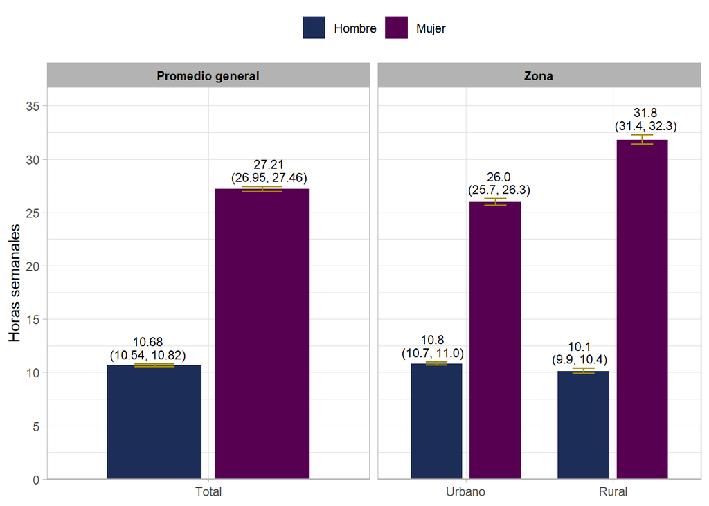

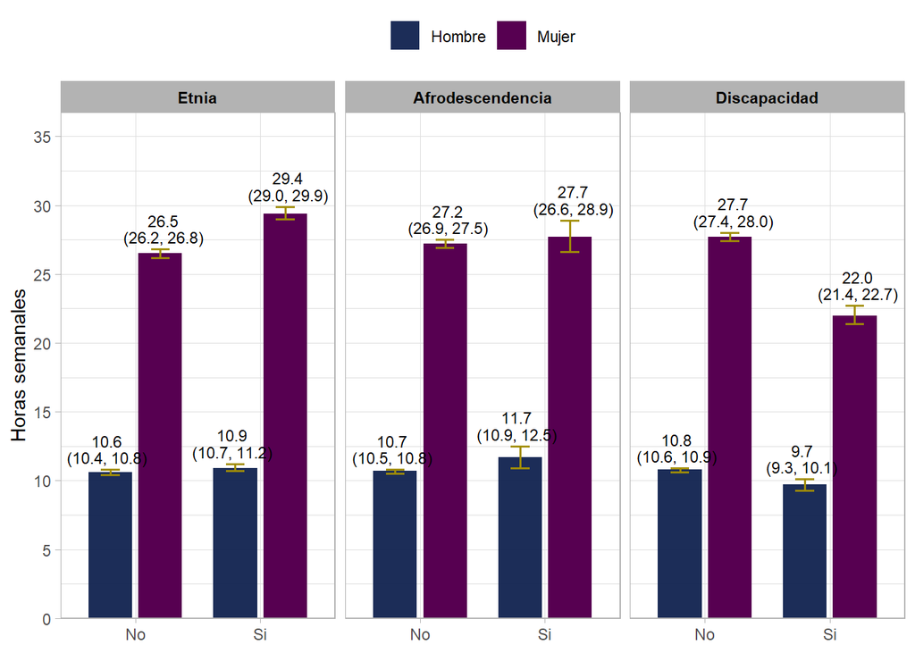

#### Quantiles (h) de TNR

Distribución de tiempo trabajo no remunerado

Mediana y rango intercuartílico (h) por sexo y variable transversal

|  | Hombres p50 (p25–p75) | Mujeres p50 (p25–p75) |
| --- | --- | --- |
| Afrodescendencia |  |  |
| No | 7.0 (1.0–14.0) | 21.0 (10.0–40.0) |
| Si | 7.0 (2.0–15.0) | 21.0 (10.0–40.0) |
| Discapacidad |  |  |
| No | 7.0 (2.0–14.0) | 21.0 (10.0–40.0) |
| Si | 5.0 (0.0–14.0) | 15.0 (4.0–35.0) |
| Etnia |  |  |
| No | 7.0 (1.0–14.0) | 20.0 (9.0–39.0) |
| Si | 7.0 (1.0–14.0) | 23.0 (12.0–42.0) |
| Pobreza |  |  |
| Pobreza extrema | 7.0 (0.0–15.0) | 30.0 (14.0–50.0) |
| Pobreza por ingresos | 7.0 (0.0–14.0) | 25.0 (12.0–45.0) |
| No pobre por ingresos | 7.0 (2.0–14.0) | 20.0 (8.0–35.0) |
| Zona |  |  |
| Urbano | 7.0 (2.0–14.0) | 20.0 (8.5–36.0) |
| Rural | 7.0 (0.0–14.0) | 28.0 (14.0–46.0) |

## Tiempo personal

Promedio de tiempo personal por sexo

Estimaciones ENIGH 2024 México

| variable | Hombre | Mujer | p_valor |
| --- | --- | --- | --- |
| Tiempo personal (horas) | 20.69 (20.47, 20.91) | 19.59 (19.39, 19.80) | <0.001 |

### Tiempo personal por transversales

#### Medias (h) de t personal

Tiempo personal por sexo

Promedio de horas semanales, ENIGH 2024 México

|  | Hombres Media (IC95%) | Mujeres Media (IC95%) | p |
| --- | --- | --- | --- |
| Zona |  |  |  |
| Urbano | 20.5 (20.2, 20.7) | 19.5 (19.2, 19.7) | <0.001 |
| Rural | 21.5 (21.0, 22.0) | 20.1 (19.7, 20.5) | <0.001 |
| Etnia |  |  |  |
| No | 20.7 (20.5, 21.0) | 19.7 (19.4, 19.9) | <0.001 |
| Si | 20.7 (20.3, 21.0) | 19.4 (19.1, 19.8) | <0.001 |
| Afrodescendencia |  |  |  |
| No | 20.7 (20.5, 20.9) | 19.6 (19.4, 19.8) | <0.001 |
| Si | 20.4 (19.5, 21.4) | 19.4 (18.4, 20.3) | 0.027 |
| Discapacidad |  |  |  |
| No | 19.9 (19.7, 20.1) | 18.9 (18.7, 19.1) | <0.001 |
| Si | 29.1 (28.4, 29.8) | 26.8 (26.1, 27.4) | <0.001 |
| Pobreza |  |  |  |
| Pobreza extrema | 20.9 (20.2, 21.7) | 18.8 (18.2, 19.4) | <0.001 |
| Pobreza por ingresos | 20.3 (19.9, 20.7) | 18.8 (18.4, 19.1) | <0.001 |
| No pobre por ingresos | 20.8 (20.6, 21.0) | 20.0 (19.8, 20.2) | <0.001 |

#### Quantiles (h) de t personal

Distribución quantiles tiempo personal por sexo

Mediana y rango intercuartílico

|  | Hombres p50 (p25–p75) | Mujeres p50 (p25–p75) |
| --- | --- | --- |
| Afrodescendencia |  |  |
| No | 15.0 (10.0–28.0) | 14.0 (8.0–26.0) |
| Si | 15.0 (8.0–28.0) | 14.0 (7.0–25.0) |
| Discapacidad |  |  |
| No | 15.0 (9.0–28.0) | 14.0 (8.0–25.0) |
| Si | 21.0 (10.0–42.0) | 20.0 (9.5–40.0) |
| Etnia |  |  |
| No | 15.0 (10.0–28.0) | 14.0 (8.0–27.0) |
| Si | 15.0 (8.0–28.0) | 14.0 (7.0–25.0) |
| Pobreza |  |  |
| Pobreza extrema | 15.0 (8.0–28.0) | 14.0 (7.0–25.0) |
| Pobreza por ingresos | 15.0 (9.0–28.0) | 14.0 (7.0–24.0) |
| No pobre por ingresos | 15.0 (10.0–28.0) | 14.0 (8.0–28.0) |
| Zona |  |  |
| Urbano | 15.0 (10.0–28.0) | 14.0 (8.0–25.0) |
| Rural | 15.0 (9.0–28.0) | 14.0 (7.0–28.0) |

## Dependencia económica

En este bloque vemos la dependencia económica usando la variable de 3 categorias: si/no/no calculable  
Recordar que “No calculable” se le asignó a aquellas personas que tuvieron NA en reporte de ingresos de manera individual

Dependencia económica

Estimaciones ponderadas, ENIGH 2024 México

|  | Hombres n | Hombres % (IC95%) | Mujeres n | Mujeres % (IC95%) | p_valor |  |
| --- | --- | --- | --- | --- | --- | --- |
| Dependencia económica : No | 34456876 | 67.6% (67.2, 68.0) | 23387836 | 40.9% (40.5, 41.4) |  | <0.001 |
| Dependencia económica : Si | 8901013 | 17.5% (17.1, 17.8) | 16108442 | 28.2% (27.8, 28.6) | <0.001 |  |
| Dependencia económica : No calculable | 7614253 | 14.9% (14.6, 15.3) | 17640370 | 30.9% (30.4, 31.3) | <0.001 |  |

### Dependencia económica por transversales

Dependencia económica por variables transversales

|  | Categoría | Hombres n (%) | Mujeres n (%) | p |
| --- | --- | --- | --- | --- |
| Zona |  |  |  |  |
| Urbano | Dependencia económica : No | 27857150 (69.0% (68.5, 69.5)) | 19832530 (43.8% (43.3, 44.4)) | <0.001 |
| Urbano | Dependencia económica : Si | 6347903 (15.7% (15.3, 16.2)) | 11830578 (26.1% (25.6, 26.6)) | <0.001 |
| Urbano | Dependencia económica : No calculable | 6145958 (15.2% (14.8, 15.6)) | 13587236 (30.0% (29.5, 30.6)) | <0.001 |
| Rural | Dependencia económica : No | 6599726 (62.1% (61.2, 63.1)) | 3555306 (29.9% (29.1, 30.7)) | <0.001 |
| Rural | Dependencia económica : Si | 2553110 (24.0% (23.2, 24.9)) | 4277864 (36.0% (35.2, 36.8)) | <0.001 |
| Rural | Dependencia económica : No calculable | 1468295 (13.8% (13.3, 14.4)) | 4053134 (34.1% (33.3, 34.9)) | <0.001 |
| Etnia |  |  |  |  |
| No | Dependencia económica : No | 26981256 (69.2% (68.7, 69.7)) | 18816734 (43.3% (42.8, 43.8)) | <0.001 |
| No | Dependencia económica : Si | 6128628 (15.7% (15.3, 16.1)) | 11223439 (25.8% (25.3, 26.3)) | <0.001 |
| No | Dependencia económica : No calculable | 5904796 (15.1% (14.7, 15.5)) | 13403029 (30.9% (30.3, 31.4)) | <0.001 |
| Si | Dependencia económica : No | 7475620 (62.5% (61.6, 63.5)) | 4571102 (33.4% (32.5, 34.3)) | <0.001 |
| Si | Dependencia económica : Si | 2772385 (23.2% (22.4, 24.0)) | 4885003 (35.7% (34.8, 36.5)) | <0.001 |
| Si | Dependencia económica : No calculable | 1709457 (14.3% (13.6, 14.9)) | 4237341 (30.9% (30.0, 31.9)) | <0.001 |
| Afrodescendencia |  |  |  |  |
| No | Dependencia económica : No | 33470104 (67.6% (67.1, 68.0)) | 22781259 (41.0% (40.6, 41.5)) | <0.001 |
| No | Dependencia económica : Si | 8642218 (17.5% (17.1, 17.8)) | 15626832 (28.1% (27.7, 28.6)) | <0.001 |
| No | Dependencia económica : No calculable | 7400059 (14.9% (14.6, 15.3)) | 17140752 (30.9% (30.4, 31.3)) | <0.001 |
| Si | Dependencia económica : No | 986772 (67.6% (64.9, 70.2)) | 606577 (38.2% (35.8, 40.6)) | <0.001 |
| Si | Dependencia económica : Si | 258795 (17.7% (15.6, 19.9)) | 481610 (30.3% (27.9, 32.8)) | <0.001 |
| Si | Dependencia económica : No calculable | 214194 (14.7% (12.9, 16.4)) | 499618 (31.5% (29.2, 33.7)) | <0.001 |
| Discapacidad |  |  |  |  |
| No | Dependencia económica : No | 32190683 (68.9% (68.4, 69.3)) | 21614921 (41.4% (40.9, 41.9)) | <0.001 |
| No | Dependencia económica : Si | 7453450 (15.9% (15.6, 16.3)) | 13869826 (26.6% (26.1, 27.0)) | <0.001 |
| No | Dependencia económica : No calculable | 7099794 (15.2% (14.8, 15.6)) | 16731727 (32.0% (31.6, 32.5)) | <0.001 |
| Si | Dependencia económica : No | 2253331 (54.8% (53.3, 56.3)) | 1765316 (36.4% (35.0, 37.7)) | <0.001 |
| Si | Dependencia económica : Si | 1384450 (33.7% (32.3, 35.0)) | 2204728 (45.4% (44.0, 46.8)) | <0.001 |
| Si | Dependencia económica : No calculable | 472221 (11.5% (10.5, 12.5)) | 885996 (18.2% (17.1, 19.4)) | <0.001 |

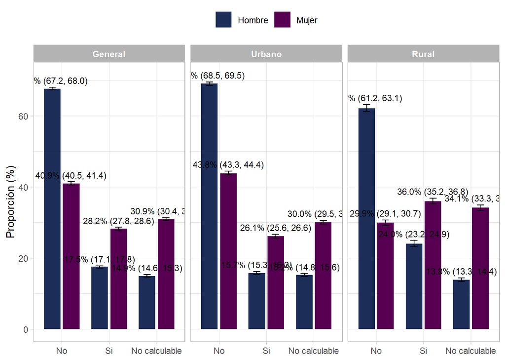

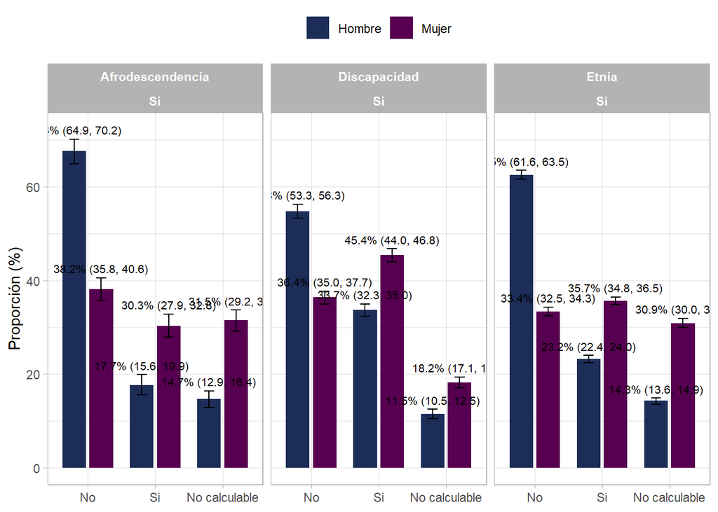

## Tipo jefatura

| variable | categoria | n_Hombre | prop_ic_Hombre | n_Mujer | prop_ic_Mujer | p_valor |
| --- | --- | --- | --- | --- | --- | --- |
| Jefatura por sexo | Biparental | 16046603 | 92.5% (92.0, 92.9) | 1639717 | 18.7% (17.9, 19.5) | <0.001 |
| Jefatura por sexo | Uniparental | 1308522 | 7.5% (7.1, 8.0) | 7126941 | 81.3% (80.5, 82.1) | <0.001 |

### Transversales en jefatura

| variable | categoria | transversal | prop_ic_Hombre | prop_ic_Mujer | n_Hombre | n_Mujer | p_valor |
| --- | --- | --- | --- | --- | --- | --- | --- |
| Tipo jefatura | Biparental | Urbano | 91.9% (91.4, 92.4) | 19.0% (18.1, 19.9) | 12268131 | 1379696 | <0.001 |
| Tipo jefatura | Uniparental | Urbano | 8.1% (7.6, 8.6) | 81.0% (80.1, 81.9) | 1081762 | 5869418 | <0.001 |
| Tipo jefatura | Biparental | Rural | 94.3% (93.6, 95.1) | 17.1% (15.9, 18.4) | 3778472 | 260021 | <0.001 |
| Tipo jefatura | Uniparental | Rural | 5.7% (4.9, 6.4) | 82.9% (81.6, 84.1) | 226760 | 1257523 | <0.001 |

| variable | categoria | transversal | prop_ic_Hombre | prop_ic_Mujer | n_Hombre | n_Mujer | p_valor |
| --- | --- | --- | --- | --- | --- | --- | --- |
| Autopercepción indígena | Biparental | No | 92.4% (91.9, 92.9) | 18.6% (17.7, 19.5) | 12028891 | 1262999 | <0.001 |
| Autopercepción indígena | Uniparental | No | 7.6% (7.1, 8.1) | 81.4% (80.5, 82.3) | 995735 | 5534381 | <0.001 |
| Autopercepción indígena | Biparental | Si | 92.8% (92.1, 93.5) | 19.1% (17.6, 20.7) | 4017712 | 376718 | <0.001 |
| Autopercepción indígena | Uniparental | Si | 7.2% (6.5, 7.9) | 80.9% (79.3, 82.4) | 312787 | 1592560 | <0.001 |

| variable | categoria | transversal | prop_ic_Hombre | prop_ic_Mujer | n_Hombre | n_Mujer | p_valor |
| --- | --- | --- | --- | --- | --- | --- | --- |
| Afrodescendencia | Biparental | No | 92.4% (92.0, 92.8) | 18.8% (18.0, 19.5) | 15608049 | 1596019 | <0.001 |
| Afrodescendencia | Uniparental | No | 7.6% (7.2, 8.0) | 81.2% (80.5, 82.0) | 1280946 | 6915715 | <0.001 |
| Afrodescendencia | Biparental | Si | 94.1% (92.2, 95.9) | 17.1% (12.9, 21.3) | 438554 | 43698 | <0.001 |
| Afrodescendencia | Uniparental | Si | 5.9% (4.1, 7.8) | 82.9% (78.7, 87.1) | 27576 | 211226 | <0.001 |

| variable | categoria | transversal | prop_ic_Hombre | prop_ic_Mujer | n_Hombre | n_Mujer | p_valor |
| --- | --- | --- | --- | --- | --- | --- | --- |
| Discapacidad | Biparental | No | 93.2% (92.8, 93.6) | 19.8% (18.9, 20.7) | 14722417 | 1488979 | <0.001 |
| Discapacidad | Uniparental | No | 6.8% (6.4, 7.2) | 80.2% (79.3, 81.1) | 1074328 | 6036549 | <0.001 |
| Discapacidad | Biparental | Si | 85.1% (83.3, 86.9) | 12.2% (10.2, 14.3) | 1300154 | 150738 | <0.001 |
| Discapacidad | Uniparental | Si | 14.9% (13.1, 16.7) | 87.8% (85.7, 89.8) | 227778 | 1084291 | <0.001 |

| variable | categoria | transversal | prop_ic_Hombre | prop_ic_Mujer | n_Hombre | n_Mujer | p_valor |
| --- | --- | --- | --- | --- | --- | --- | --- |
| Pobreza | Biparental | Pobreza extrema | 96.9% (96.3, 97.6) | 18.8% (15.8, 21.9) | 1445218 | 101868 | <0.001 |
| Pobreza | Uniparental | Pobreza extrema | 3.1% (2.4, 3.7) | 81.2% (78.1, 84.2) | 45481 | 439094 | <0.001 |
| Pobreza | Biparental | Pobreza por ingresos | 95.2% (94.7, 95.8) | 19.2% (17.7, 20.8) | 4479802 | 406345 | <0.001 |
| Pobreza | Uniparental | Pobreza por ingresos | 4.8% (4.2, 5.3) | 80.8% (79.2, 82.3) | 223840 | 1707563 | <0.001 |
| Pobreza | Biparental | No pobre por ingresos | 90.7% (90.1, 91.3) | 18.5% (17.6, 19.4) | 10121583 | 1131504 | <0.001 |
| Pobreza | Uniparental | No pobre por ingresos | 9.3% (8.7, 9.9) | 81.5% (80.6, 82.4) | 1039201 | 4980284 | <0.001 |

## Acceso financiero por hogar

| variable | categoria | n_Hombre | prop_ic_Hombre | n_Mujer | prop_ic_Mujer | p_valor |
| --- | --- | --- | --- | --- | --- | --- |
| Acceso financiero por sexo de jefatura del hogar | No | 17938852 | 69.5% (68.8, 70.2) | 9012819 | 69.2% (68.3, 70.2) | 0.578 |
| Acceso financiero por sexo de jefatura del hogar | Si | 7859016 | 30.5% (29.8, 31.2) | 4002109 | 30.8% (29.8, 31.7) | 0.578 |

| variable | categoria | transversal | prop_ic_Hombre | prop_ic_Mujer | n_Hombre | n_Mujer | p_valor |
| --- | --- | --- | --- | --- | --- | --- | --- |
| Acceso financiero | No | Urbano | 63.5% (62.6, 64.4) | 65.0% (63.9, 66.0) | 12733003 | 7030247 | 0.020 |
| Acceso financiero | Si | Urbano | 36.5% (35.6, 37.4) | 35.0% (34.0, 36.1) | 7312560 | 3792870 | 0.020 |
| Acceso financiero | No | Rural | 90.5% (89.8, 91.2) | 90.5% (89.5, 91.4) | 5205849 | 1982572 | 0.928 |
| Acceso financiero | Si | Rural | 9.5% (8.8, 10.2) | 9.5% (8.6, 10.5) | 546456 | 209239 | 0.928 |

| variable | categoria | transversal | prop_ic_Hombre | prop_ic_Mujer | n_Hombre | n_Mujer | p_valor |
| --- | --- | --- | --- | --- | --- | --- | --- |
| Acceso financiero | No | No | 65.0% (64.1, 65.9) | 65.6% (64.5, 66.7) | 12630663 | 6577502 | 0.345 |
| Acceso financiero | Si | No | 35.0% (34.1, 35.9) | 34.4% (33.3, 35.5) | 6799401 | 3451724 | 0.345 |
| Acceso financiero | No | Si | 83.4% (82.4, 84.3) | 81.6% (80.2, 82.9) | 5308189 | 2435317 | 0.024 |
| Acceso financiero | Si | Si | 16.6% (15.7, 17.6) | 18.4% (17.1, 19.8) | 1059615 | 550385 | 0.024 |

| variable | categoria | transversal | prop_ic_Hombre | prop_ic_Mujer | n_Hombre | n_Mujer | p_valor |
| --- | --- | --- | --- | --- | --- | --- | --- |
| Acceso financiero | No | No | 69.5% (68.8, 70.2) | 69.1% (68.2, 70.0) | 17411331 | 8739770 | 0.442 |
| Acceso financiero | Si | No | 30.5% (29.8, 31.2) | 30.9% (30.0, 31.8) | 7646800 | 3911421 | 0.442 |
| Acceso financiero | No | Si | 71.3% (67.8, 74.8) | 75.1% (70.8, 79.3) | 527521 | 273049 | 0.183 |
| Acceso financiero | Si | Si | 28.7% (25.2, 32.2) | 24.9% (20.7, 29.2) | 212216 | 90688 | 0.183 |

| variable | categoria | transversal | prop_ic_Hombre | prop_ic_Mujer | n_Hombre | n_Mujer | p_valor |
| --- | --- | --- | --- | --- | --- | --- | --- |
| Acceso financiero | No | No | 68.4% (67.7, 69.2) | 68.2% (67.2, 69.1) | 15803920 | 7510647 | 0.674 |
| Acceso financiero | Si | No | 31.6% (30.8, 32.3) | 31.8% (30.9, 32.8) | 7295093 | 3504127 | 0.674 |
| Acceso financiero | No | Si | 79.0% (77.3, 80.6) | 75.2% (73.1, 77.3) | 2091701 | 1498889 | 0.005 |
| Acceso financiero | Si | Si | 21.0% (19.4, 22.7) | 24.8% (22.7, 26.9) | 557074 | 493306 | 0.005 |

| variable | categoria | transversal | prop_ic_Hombre | prop_ic_Mujer | n_Hombre | n_Mujer | p_valor |
| --- | --- | --- | --- | --- | --- | --- | --- |
| Acceso financiero | No | Pobreza extrema | 95.3% (94.4, 96.3) | 94.6% (92.6, 96.7) | 1611557 | 579099 | 0.511 |
| Acceso financiero | Si | Pobreza extrema | 4.7% (3.7, 5.6) | 5.4% (3.3, 7.4) | 78955 | 33002 | 0.511 |
| Acceso financiero | No | Pobreza por ingresos | 88.1% (87.2, 89.0) | 87.5% (85.7, 89.4) | 4862224 | 2212360 | 0.530 |
| Acceso financiero | Si | Pobreza por ingresos | 11.9% (11.0, 12.8) | 12.5% (10.6, 14.3) | 654080 | 315099 | 0.530 |
| Acceso financiero | No | No pobre por ingresos | 61.7% (60.8, 62.5) | 63.0% (62.0, 64.0) | 11465071 | 6221360 | 0.031 |
| Acceso financiero | Si | No pobre por ingresos | 38.3% (37.5, 39.2) | 37.0% (36.0, 38.0) | 7125981 | 3654008 | 0.031 |

## Acceso propiedad vivienda

| variable | categoria | transversal | prop_ic_Hombre | prop_ic_Mujer | n_Hombre | n_Mujer | p_valor |
| --- | --- | --- | --- | --- | --- | --- | --- |
| Acceso propiedad | No | Urbano | 58.0% (57.4, 58.7) | 69.2% (68.7, 69.8) | 11483332 | 15575412 | <0.001 |
| Acceso propiedad | Si | Urbano | 42.0% (41.3, 42.6) | 30.8% (30.2, 31.3) | 8306649 | 6916887 | <0.001 |
| Acceso propiedad | No | Rural | 51.0% (50.1, 51.9) | 77.3% (76.4, 78.2) | 2273666 | 3781582 | <0.001 |
| Acceso propiedad | Si | Rural | 49.0% (48.1, 49.9) | 22.7% (21.8, 23.6) | 2184023 | 1108887 | <0.001 |

| variable | categoria | transversal | prop_ic_Hombre | prop_ic_Mujer | n_Hombre | n_Mujer | p_valor |
| --- | --- | --- | --- | --- | --- | --- | --- |
| Acceso propiedad | No | No | 57.7% (57.1, 58.4) | 70.2% (69.6, 70.7) | 10974322 | 14984816 | <0.001 |
| Acceso propiedad | Si | No | 42.3% (41.6, 42.9) | 29.8% (29.3, 30.4) | 8036156 | 6375586 | <0.001 |
| Acceso propiedad | No | Si | 53.1% (52.0, 54.3) | 72.6% (71.5, 73.7) | 2782676 | 4372178 | <0.001 |
| Acceso propiedad | Si | Si | 46.9% (45.7, 48.0) | 27.4% (26.3, 28.5) | 2454516 | 1650188 | <0.001 |

| variable | categoria | transversal | prop_ic_Hombre | prop_ic_Mujer | n_Hombre | n_Mujer | p_valor |
| --- | --- | --- | --- | --- | --- | --- | --- |
| Acceso propiedad | No | No | 56.7% (56.1, 57.2) | 70.7% (70.2, 71.2) | 13366817 | 18838096 | <0.001 |
| Acceso propiedad | Si | No | 43.3% (42.8, 43.9) | 29.3% (28.8, 29.8) | 10221887 | 7819449 | <0.001 |
| Acceso propiedad | No | Si | 59.2% (55.9, 62.5) | 71.6% (68.7, 74.4) | 390181 | 518898 | <0.001 |
| Acceso propiedad | Si | Si | 40.8% (37.5, 44.1) | 28.4% (25.6, 31.3) | 268785 | 206325 | <0.001 |

| variable | categoria | transversal | prop_ic_Hombre | prop_ic_Mujer | n_Hombre | n_Mujer | p_valor |
| --- | --- | --- | --- | --- | --- | --- | --- |
| Acceso propiedad | No | No | 58.3% (57.6, 58.9) | 72.7% (72.1, 73.2) | 12868061 | 18072756 | <0.001 |
| Acceso propiedad | Si | No | 41.7% (41.1, 42.4) | 27.3% (26.8, 27.9) | 9221614 | 6797709 | <0.001 |
| Acceso propiedad | No | Si | 40.6% (38.7, 42.5) | 50.9% (49.0, 52.8) | 853347 | 1259183 | <0.001 |
| Acceso propiedad | Si | Si | 59.4% (57.5, 61.3) | 49.1% (47.2, 51.0) | 1246203 | 1216835 | <0.001 |

| variable | categoria | transversal | prop_ic_Hombre | prop_ic_Mujer | n_Hombre | n_Mujer | p_valor |
| --- | --- | --- | --- | --- | --- | --- | --- |
| Acceso propiedad | No | Pobreza extrema | 57.2% (54.9, 59.5) | 82.3% (80.6, 84.0) | 662367 | 1151139 | <0.001 |
| Acceso propiedad | Si | Pobreza extrema | 42.8% (40.5, 45.1) | 17.7% (16.0, 19.4) | 496114 | 247987 | <0.001 |
| Acceso propiedad | No | Pobreza por ingresos | 60.5% (59.3, 61.7) | 78.1% (77.2, 79.0) | 2753621 | 4359491 | <0.001 |
| Acceso propiedad | Si | Pobreza por ingresos | 39.5% (38.3, 40.7) | 21.9% (21.0, 22.8) | 1799118 | 1220798 | <0.001 |
| Acceso propiedad | No | No pobre por ingresos | 55.8% (55.1, 56.4) | 67.9% (67.2, 68.5) | 10341010 | 13846364 | <0.001 |
| Acceso propiedad | Si | No pobre por ingresos | 44.2% (43.6, 44.9) | 32.1% (31.5, 32.8) | 8195440 | 6556989 | <0.001 |

## Mercado laboral

Acceso a mercado laboral

|  | Hombres n | Hombres % (IC95%) | Mujeres n | Mujeres % (IC95%) | p_valor |  |
| --- | --- | --- | --- | --- | --- | --- |
| Mercado laboral : Formal | 14465608 | 39.4% (38.8, 40.0) | 10164381 | 37.1% (36.5, 37.8) |  | <0.001 |
| Mercado laboral : Informal profesional | 3150168 | 8.6% (8.3, 8.9) | 2657896 | 9.7% (9.3, 10.1) | <0.001 |  |
| Mercado laboral : Informal no profesional | 19101601 | 52.0% (51.4, 52.7) | 14546742 | 53.2% (52.5, 53.8) | <0.001 |  |

Acceso a mercado laboral por variables transversales

|  | Categoría | Hombres n (%) | Mujeres n (%) | p |
| --- | --- | --- | --- | --- |
| Zona |  |  |  |  |
| Urbano | Formalidad laboral : Formal | 13148404 (46.3% (45.6, 47.1)) | 9450418 (43.0% (42.2, 43.8)) | <0.001 |
| Urbano | Formalidad laboral : Informal profesional | 2843402 (10.0% (9.6, 10.4)) | 2394770 (10.9% (10.4, 11.4)) | <0.001 |
| Urbano | Formalidad laboral : Informal no profesional | 12377211 (43.6% (42.9, 44.4)) | 10117859 (46.1% (45.3, 46.9)) | <0.001 |
| Rural | Formalidad laboral : Formal | 1317204 (15.8% (14.9, 16.7)) | 713963 (13.2% (12.3, 14.1)) | <0.001 |
| Rural | Formalidad laboral : Informal profesional | 306766 (3.7% (3.4, 4.0)) | 263126 (4.9% (4.4, 5.3)) | <0.001 |
| Rural | Formalidad laboral : Informal no profesional | 6724390 (80.5% (79.6, 81.5)) | 4428883 (81.9% (80.9, 82.9)) | <0.001 |
| Etnia |  |  |  |  |
| No | Formalidad laboral : Formal | 12156695 (44.1% (43.4, 44.9)) | 8639301 (42.1% (41.3, 42.9)) | <0.001 |
| No | Formalidad laboral : Informal profesional | 2624142 (9.5% (9.1, 9.9)) | 2193904 (10.7% (10.2, 11.1)) | <0.001 |
| No | Formalidad laboral : Informal no profesional | 12756751 (46.3% (45.6, 47.1)) | 9706943 (47.3% (46.4, 48.1)) | <0.001 |
| Si | Formalidad laboral : Formal | 2308913 (25.2% (24.1, 26.2)) | 1525080 (22.3% (21.2, 23.5)) | <0.001 |
| Si | Formalidad laboral : Informal profesional | 526026 (5.7% (5.3, 6.2)) | 463992 (6.8% (6.2, 7.4)) | <0.001 |
| Si | Formalidad laboral : Informal no profesional | 6344850 (69.1% (68.0, 70.3)) | 4839799 (70.9% (69.6, 72.1)) | <0.001 |
| Afrodescendencia |  |  |  |  |
| No | Formalidad laboral : Formal | 14076660 (39.5% (38.9, 40.1)) | 9902215 (37.2% (36.5, 37.9)) | <0.001 |
| No | Formalidad laboral : Informal profesional | 3051788 (8.6% (8.2, 8.9)) | 2584992 (9.7% (9.3, 10.1)) | <0.001 |
| No | Formalidad laboral : Informal no profesional | 18513766 (51.9% (51.3, 52.6)) | 14130725 (53.1% (52.4, 53.8)) | <0.001 |
| Si | Formalidad laboral : Formal | 388948 (36.2% (33.0, 39.3)) | 262166 (34.9% (31.4, 38.4)) | 0.801 |
| Si | Formalidad laboral : Informal profesional | 98380 (9.2% (7.1, 11.2)) | 72904 (9.7% (7.6, 11.9)) | 0.801 |
| Si | Formalidad laboral : Informal no profesional | 587835 (54.7% (51.2, 58.1)) | 416017 (55.4% (51.7, 59.1)) | 0.801 |
| Discapacidad |  |  |  |  |
| No | Formalidad laboral : Formal | 13987612 (40.2% (39.5, 40.8)) | 9802833 (37.8% (37.1, 38.5)) | <0.001 |
| No | Formalidad laboral : Informal profesional | 3031171 (8.7% (8.4, 9.0)) | 2580551 (10.0% (9.6, 10.3)) | <0.001 |
| No | Formalidad laboral : Informal no profesional | 17807225 (51.1% (50.5, 51.8)) | 13544607 (52.2% (51.5, 52.9)) | <0.001 |
| Si | Formalidad laboral : Formal | 477996 (25.3% (23.2, 27.3)) | 361548 (25.1% (22.9, 27.3)) | 0.498 |
| Si | Formalidad laboral : Informal profesional | 118997 (6.3% (5.2, 7.4)) | 77345 (5.4% (4.2, 6.5)) | 0.498 |
| Si | Formalidad laboral : Informal no profesional | 1294376 (68.4% (66.3, 70.6)) | 1002135 (69.5% (67.2, 71.9)) | 0.498 |
| Pobreza |  |  |  |  |
| No pobre por ingresos | Formalidad laboral : Formal | 12395053 (47.4% (46.7, 48.1)) | 9153798 (45.9% (45.1, 46.6)) | <0.001 |
| No pobre por ingresos | Formalidad laboral : Informal profesional | 2699207 (10.3% (9.9, 10.7)) | 2223628 (11.1% (10.7, 11.6)) | <0.001 |
| No pobre por ingresos | Formalidad laboral : Informal no profesional | 11058039 (42.3% (41.6, 43.0)) | 8578525 (43.0% (42.2, 43.7)) | <0.001 |
| Pobreza por ingresos | Formalidad laboral : Formal | 1918382 (23.6% (22.6, 24.7)) | 957974 (16.5% (15.4, 17.6)) | <0.001 |
| Pobreza por ingresos | Formalidad laboral : Informal profesional | 391026 (4.8% (4.3, 5.3)) | 384532 (6.6% (5.9, 7.3)) | <0.001 |
| Pobreza por ingresos | Formalidad laboral : Informal no profesional | 5805177 (71.5% (70.4, 72.6)) | 4470603 (76.9% (75.6, 78.2)) | <0.001 |
| Pobreza extrema | Formalidad laboral : Formal | 152173 (6.2% (5.1, 7.3)) | 52609 (3.3% (2.5, 4.1)) | <0.001 |
| Pobreza extrema | Formalidad laboral : Informal profesional | 59935 (2.4% (1.9, 3.0)) | 49736 (3.1% (2.3, 3.9)) | <0.001 |
| Pobreza extrema | Formalidad laboral : Informal no profesional | 2238385 (91.3% (90.1, 92.5)) | 1497614 (93.6% (92.4, 94.8)) | <0.001 |